# Adaptive CMA-ES configurations - Analysis

This Python Notebook covers the analysis of pre-processed data for the adaptive CMA-ES research.

The most important information about the data is that the `steepness` is calculated as $\dfrac{1}{\delta_e}$, where $\delta_e$ is the number of evaluations between 'entering' and 'leaving' the specified section of fitness values.

An example with section boundaries 100, 1 and 0.01:

`idx | 1 2 3 ... 56 57 58 59 ... 164 165 166 167`  
`val | 124 102 94 ... 1.13 1.06 0.98 0.96 ... 0.0123 0.0109 0.0098 0.0097`

For section `$\inf$-100`, the first index where the value is *below* 100 is 3. The steepness is then $\frac{1}{3-0} = 0.33\ldots$. For the next section (boundary 1), the index is 58, giving a steepness of $\frac{1}{58-3} = 0.01818\ldots$, and for the final section the first index is 166 for a steepness of $\frac{1}{166-58} = 0.00925\ldots$.

Because the steepness is calculated as $\frac{1}{\delta_e}$, higher values are better, meaning we can easily discard zeros as sections that were either skipped or never reached at all.

> Sander van Rijn  
> s.j.van.rijn@liacs.leidenuniv.nl  
> LIACS  
> 2018-03-01

## Initialization

```python
%matplotlib inline

from __future__ import division, print_function

import os
import numpy as np
import pandas as pd
import matplotlib.pyplot as plt
from itertools import product
from collections import Counter
```

```python
# Some utility functions for dealing with the representations

# First, some hardcoded variables
num_options_per_module = [2]*9        # Binary part
num_options_per_module.extend([3]*2)  # Ternary part
max_length = 11
factors = [2304, 1152, 576, 288, 144, 72, 36, 18, 9, 3, 1]

def list_all_representations():
    """ Create a list of all possible representations for the modular CMA-ES.
        Each representation is itself a list with <max_length> integer entries {0, 1, ..., n},
        where 'n' is the number of options for the module in that position.
    """
    products = []
    # count how often there is a choice of x options
    counts = Counter(num_options_per_module)
    for num, count in sorted(counts.items(), key=lambda x: x[0]):
        products.append(product(range(num), repeat=count))
    all_representations = []
    for representation in list(product(*products)):
        all_representations.append(list(sum(representation, ())))
    return all_representations


def reprToString(representation):
    """ Function that converts the structure parameters of a given ES-structure representation to a string

        >>> reprToInt([0,0,0,0,0,1,0,1,0,1,0])
        >>> '00000101010'
    """
    return ''.join([str(i) for i in representation[:max_length]])
```

```python
data_location = '/media/rijnsjvan/Data/SurfDrive/Research Data/Adaptive ES/anytime_convergence/data/'
file_name = 'steepness_data_{ndim}D-f{fid}.csv'

#TODO: Retrieve this information from the files instead?
ndims = [5, 20]
fids = [1, 10, 15, 20]

num_steps = 51
powers = np.round(np.linspace(2, -8, num_steps), decimals=1)
target_values = np.power([10]*num_steps, powers)

columns = ['10e{}'.format(power) for power in powers]


np.set_printoptions(linewidth=1000, edgeitems=30)
pd.set_option('display.max_columns', 60)
pd.set_option('display.width', 1000)
```

# Exploration

Using the data in (one of) the CSV files, we'll start with some exploratory analysis. Any useful procedures will be coded as functions, making them easy to re-use for a final full analysis later on.

```python
def get_data(ndim, fid):
    return pd.read_csv(data_location + file_name.format(ndim=ndim, fid=fid), index_col=0)

# Starting with 5D F1 as an example
df = get_data(ndim=5, fid=1)
df.head()
```

|  | Representation | ndim | function ID | instance ID | repetition | 10e2.0 | 10e1.8 | 10e1.6 | 10e1.4 | 10e1.2 | 10e1.0 | 10e0.8 | 10e0.6 | 10e0.4 | 10e0.2 | 10e0.0 | 10e-0.2 | 10e-0.4 | 10e-0.6 | 10e-0.8 | 10e-1.0 | 10e-1.2 | 10e-1.4 | 10e-1.6 | 10e-1.8 | 10e-2.0 | 10e-2.2 | 10e-2.4 | 10e-2.6 | … |
| --- | --- | --- | --- | --- | --- | --- | --- | --- | --- | --- | --- | --- | --- | --- | --- | --- | --- | --- | --- | --- | --- | --- | --- | --- | --- | --- | --- | --- | --- | --- |
| 0 | [0, 0, 0, 0, 0, 0, 0, 0, 0, 0, 0] | 5 | 1 | 0 | 0 | 0.0 | 0.0 | 1.0 | 9.0 | 13.0 | 210.0 | 254.0 | 269.0 | 274.0 | 274.0 | 292.0 | 327.0 | 344.0 | 367.0 | 368.0 | 368.0 | 380.0 | 418.0 | 428.0 | 464.0 | 473.0 | 478.0 | 512.0 | 512.0 | … |
| 1 | [0, 0, 0, 0, 0, 0, 0, 0, 0, 0, 0] | 5 | 1 | 0 | 1 | 0.0 | 0.0 | 0.0 | 4.0 | 20.0 | 155.0 | 155.0 | 155.0 | 370.0 | 370.0 | 370.0 | 370.0 | 370.0 | 495.0 | 510.0 | 510.0 | 526.0 | 536.0 | 536.0 | 536.0 | 610.0 | 624.0 | 639.0 | 639.0 | … |
| 2 | [0, 0, 0, 0, 0, 0, 0, 0, 0, 0, 0] | 5 | 1 | 0 | 2 | 0.0 | 0.0 | 16.0 | 20.0 | 24.0 | 80.0 | 80.0 | 359.0 | 366.0 | 377.0 | 399.0 | 405.0 | 418.0 | 424.0 | 436.0 | 459.0 | 476.0 | 476.0 | 539.0 | 539.0 | 539.0 | 539.0 | 563.0 | 590.0 | … |
| 3 | [0, 0, 0, 0, 0, 0, 0, 0, 0, 0, 0] | 5 | 1 | 0 | 3 | 0.0 | 0.0 | 0.0 | 0.0 | 36.0 | 36.0 | 137.0 | 406.0 | 432.0 | 433.0 | 444.0 | 444.0 | 461.0 | 461.0 | 493.0 | 493.0 | 519.0 | 519.0 | 539.0 | 567.0 | 607.0 | 616.0 | 633.0 | 642.0 | … |
| 4 | [0, 0, 0, 0, 0, 0, 0, 0, 0, 0, 0] | 5 | 1 | 0 | 4 | 0.0 | 0.0 | 1.0 | 16.0 | 32.0 | 32.0 | 32.0 | 184.0 | 206.0 | 206.0 | 240.0 | 265.0 | 279.0 | 279.0 | 310.0 | 310.0 | 312.0 | 333.0 | 367.0 | 367.0 | 377.0 | 405.0 | 410.0 | 410.0 | … |

```python
def absolutetodifferences(df):
    return_df = df.copy()
    df_columns = list(reversed(columns))
    for column_a, column_b in zip(columns, columns[1:]):
        return_df[column_b] = df[column_b] - df[column_a]
    return return_df

# Next, we get the differences between the running times for each of the targets
df_diff = absolutetodifferences(df)
df_diff.head()
```

|  | Representation | ndim | function ID | instance ID | repetition | 10e2.0 | 10e1.8 | 10e1.6 | 10e1.4 | 10e1.2 | 10e1.0 | 10e0.8 | 10e0.6 | 10e0.4 | 10e0.2 | 10e0.0 | 10e-0.2 | 10e-0.4 | 10e-0.6 | 10e-0.8 | 10e-1.0 | 10e-1.2 | 10e-1.4 | 10e-1.6 | 10e-1.8 | 10e-2.0 | 10e-2.2 | 10e-2.4 | 10e-2.6 | … |
| --- | --- | --- | --- | --- | --- | --- | --- | --- | --- | --- | --- | --- | --- | --- | --- | --- | --- | --- | --- | --- | --- | --- | --- | --- | --- | --- | --- | --- | --- | --- |
| 0 | [0, 0, 0, 0, 0, 0, 0, 0, 0, 0, 0] | 5 | 1 | 0 | 0 | 0.0 | 0.0 | 1.0 | 8.0 | 4.0 | 197.0 | 44.0 | 15.0 | 5.0 | 0.0 | 18.0 | 35.0 | 17.0 | 23.0 | 1.0 | 0.0 | 12.0 | 38.0 | 10.0 | 36.0 | 9.0 | 5.0 | 34.0 | 0.0 | … |
| 1 | [0, 0, 0, 0, 0, 0, 0, 0, 0, 0, 0] | 5 | 1 | 0 | 1 | 0.0 | 0.0 | 0.0 | 4.0 | 16.0 | 135.0 | 0.0 | 0.0 | 215.0 | 0.0 | 0.0 | 0.0 | 0.0 | 125.0 | 15.0 | 0.0 | 16.0 | 10.0 | 0.0 | 0.0 | 74.0 | 14.0 | 15.0 | 0.0 | … |
| 2 | [0, 0, 0, 0, 0, 0, 0, 0, 0, 0, 0] | 5 | 1 | 0 | 2 | 0.0 | 0.0 | 16.0 | 4.0 | 4.0 | 56.0 | 0.0 | 279.0 | 7.0 | 11.0 | 22.0 | 6.0 | 13.0 | 6.0 | 12.0 | 23.0 | 17.0 | 0.0 | 63.0 | 0.0 | 0.0 | 0.0 | 24.0 | 27.0 | … |
| 3 | [0, 0, 0, 0, 0, 0, 0, 0, 0, 0, 0] | 5 | 1 | 0 | 3 | 0.0 | 0.0 | 0.0 | 0.0 | 36.0 | 0.0 | 101.0 | 269.0 | 26.0 | 1.0 | 11.0 | 0.0 | 17.0 | 0.0 | 32.0 | 0.0 | 26.0 | 0.0 | 20.0 | 28.0 | 40.0 | 9.0 | 17.0 | 9.0 | … |
| 4 | [0, 0, 0, 0, 0, 0, 0, 0, 0, 0, 0] | 5 | 1 | 0 | 4 | 0.0 | 0.0 | 1.0 | 15.0 | 16.0 | 0.0 | 0.0 | 152.0 | 22.0 | 0.0 | 34.0 | 25.0 | 14.0 | 0.0 | 31.0 | 0.0 | 2.0 | 21.0 | 34.0 | 0.0 | 10.0 | 28.0 | 5.0 | 0.0 | … |

```python
# We can already see a problem here: Some of the smallest values are zeroes.
# This means that the actual improvement step made by the algorithm went across the specified targets.
print(df_diff[columns].min(axis=0))
```

```
10e2.0     0.0
10e1.8     0.0
10e1.6     0.0
10e1.4     0.0
10e1.2     0.0
10e1.0     0.0
10e0.8     0.0
10e0.6     0.0
10e0.4     0.0
10e0.2     0.0
10e0.0     0.0
10e-0.2    0.0
10e-0.4    0.0
10e-0.6    0.0
10e-0.8    0.0
10e-1.0    0.0
10e-1.2    0.0
10e-1.4    0.0
10e-1.6    0.0
10e-1.8    0.0
10e-2.0    0.0
10e-2.2    0.0
10e-2.4    0.0
10e-2.6    0.0
10e-2.8    0.0
10e-3.0    0.0
10e-3.2    0.0
10e-3.4    0.0
10e-3.6    0.0
10e-3.8    0.0
10e-4.0    0.0
10e-4.2    0.0
10e-4.4    0.0
10e-4.6    0.0
10e-4.8    0.0
10e-5.0    0.0
10e-5.2    0.0
10e-5.4    0.0
10e-5.6    0.0
10e-5.8    0.0
10e-6.0    0.0
10e-6.2    0.0
10e-6.4    0.0
10e-6.6    0.0
10e-6.8    0.0
10e-7.0    0.0
10e-7.2    0.0
10e-7.4    0.0
10e-7.6    0.0
10e-7.8    0.0
10e-8.0    0.0
dtype: float64
```

```python
def aggregateByMean(df):
    df_means = df.groupby(by=['Representation', 'ndim', 'function ID']).mean(numeric_only=True)
    df_means = df_means.drop(columns=['instance ID', 'repetition'])
    df_means = df_means.reset_index()
    return df_means

def aggregateByStd(df):
    df_std = df.groupby(by=['Representation', 'ndim', 'function ID']).std()
    df_std = df_std.drop(columns=['instance ID', 'repetition'])
    df_std = df_std.reset_index()
    return df_std

def aggregateByMax(df):
    df_means = df.groupby(by=['Representation', 'ndim', 'function ID']).max(axis=1)
    df_means = df_means.drop(columns=['instance ID', 'repetition'])
    df_means = df_means.reset_index()
    return df_means

def aggregateByMean(df):
    df_means = df.groupby(by=['Representation', 'ndim', 'function ID']).median(numeric_only=True)
    df_means = df_means.drop(columns=['instance ID', 'repetition'])
    df_means = df_means.reset_index()
    return df_means

# Then we can aggregate
df_diff = aggregateByMax(absolutetodifferences(df))
df_diff.head()
```

|  | Representation | ndim | function ID | 10e2.0 | 10e1.8 | 10e1.6 | 10e1.4 | 10e1.2 | 10e1.0 | 10e0.8 | 10e0.6 | 10e0.4 | 10e0.2 | 10e0.0 | 10e-0.2 | 10e-0.4 | 10e-0.6 | 10e-0.8 | 10e-1.0 | 10e-1.2 | 10e-1.4 | 10e-1.6 | 10e-1.8 | 10e-2.0 | 10e-2.2 | 10e-2.4 | 10e-2.6 | 10e-2.8 | 10e-3.0 | … |
| --- | --- | --- | --- | --- | --- | --- | --- | --- | --- | --- | --- | --- | --- | --- | --- | --- | --- | --- | --- | --- | --- | --- | --- | --- | --- | --- | --- | --- | --- | --- |
| 0 | [0, 0, 0, 0, 0, 0, 0, 0, 0, 0, 0] | 5 | 1 | 8.0 | 9.0 | 16.0 | 28.0 | 38.0 | 238.0 | 265.0 | 321.0 | 397.0 | 373.0 | 93.0 | 35.0 | 57.0 | 125.0 | 61.0 | 24.0 | 38.0 | 56.0 | 63.0 | 72.0 | 99.0 | 45.0 | 64.0 | 43.0 | 64.0 | 100.0 | … |
| 1 | [0, 0, 0, 0, 0, 0, 0, 0, 0, 0, 1] | 5 | 1 | 9.0 | 12.0 | 16.0 | 39.0 | 141.0 | 205.0 | 264.0 | 396.0 | 133.0 | 280.0 | 52.0 | 58.0 | 55.0 | 34.0 | 93.0 | 80.0 | 64.0 | 52.0 | 60.0 | 43.0 | 47.0 | 62.0 | 104.0 | 81.0 | 59.0 | 65.0 | … |
| 2 | [0, 0, 0, 0, 0, 0, 0, 0, 0, 0, 2] | 5 | 1 | 10.0 | 12.0 | 9.0 | 52.0 | 184.0 | 242.0 | 340.0 | 344.0 | 243.0 | 200.0 | 304.0 | 79.0 | 44.0 | 69.0 | 51.0 | 104.0 | 66.0 | 45.0 | 41.0 | 66.0 | 49.0 | 51.0 | 78.0 | 68.0 | 54.0 | 29.0 | … |
| 3 | [0, 0, 0, 0, 0, 0, 0, 0, 0, 1, 0] | 5 | 1 | 2.0 | 25.0 | 17.0 | 43.0 | 46.0 | 241.0 | 295.0 | 408.0 | 193.0 | 75.0 | 60.0 | 62.0 | 92.0 | 34.0 | 45.0 | 51.0 | 49.0 | 52.0 | 31.0 | 37.0 | 38.0 | 74.0 | 36.0 | 39.0 | 42.0 | 37.0 | … |
| 4 | [0, 0, 0, 0, 0, 0, 0, 0, 0, 1, 1] | 5 | 1 | 2.0 | 9.0 | 14.0 | 23.0 | 95.0 | 230.0 | 341.0 | 369.0 | 129.0 | 47.0 | 47.0 | 144.0 | 75.0 | 83.0 | 45.0 | 56.0 | 53.0 | 44.0 | 31.0 | 37.0 | 54.0 | 58.0 | 29.0 | 51.0 | 58.0 | 46.0 | … |

If we do this step before calculating the differences, it may cause problems!

```python
section_labels = ['\inf - 10e{}'.format(powers[0])]
section_labels.extend(['10e{} - 10e{}'.format(a, b) for a, b in zip(powers[:-1], powers[1:])])

def plotOnAxis(df, columns, ax, *, title=None, legend=True):
    for idx, row in df.iterrows():
        ax.plot(row[columns].values, '-', label=row['Representation'])

    ax.set_ylabel("\'steepness\'")
    ax.set_xlabel('convergence sections')
    ax.set_xticks(np.arange(len(target_values)))
    ax.set_xticklabels(section_labels)
    ax.xaxis.set_tick_params(rotation=90)
    if title:
        ax.set_title(title)
    if legend:
        ax.legend(loc=0)
```

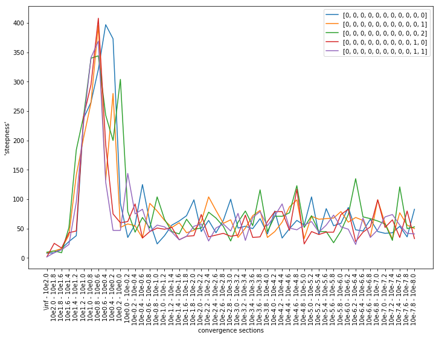

```python
# Let's plot the head (=first 5 rows) of the currently loaded data as an example
fig, ax = plt.subplots(figsize=(12,8))
plotOnAxis(df_diff.head(), columns, ax)
plt.show()
```

```python
# Extracting only the configurations that are best between a pair of targets rather than all 4,608...
def selectSmallestPerColumn(df, columns, nsmallest=1):
    indices = set()
    for col in columns:
        if df[col].max() > 0:
            new_indices = set(df[col].nsmallest(nsmallest).axes[0])
            indices = indices.union(new_indices)
    return df.iloc[sorted(indices)]

selectSmallestPerColumn(df_diff, columns).head()
```

|  | Representation | ndim | function ID | 10e2.0 | 10e1.8 | 10e1.6 | 10e1.4 | 10e1.2 | 10e1.0 | 10e0.8 | 10e0.6 | 10e0.4 | 10e0.2 | 10e0.0 | 10e-0.2 | 10e-0.4 | 10e-0.6 | 10e-0.8 | 10e-1.0 | 10e-1.2 | 10e-1.4 | 10e-1.6 | 10e-1.8 | 10e-2.0 | 10e-2.2 | 10e-2.4 | 10e-2.6 | 10e-2.8 | 10e-3.0 | … |
| --- | --- | --- | --- | --- | --- | --- | --- | --- | --- | --- | --- | --- | --- | --- | --- | --- | --- | --- | --- | --- | --- | --- | --- | --- | --- | --- | --- | --- | --- | --- |
| 34 | [0, 0, 0, 0, 0, 0, 0, 1, 1, 2, 1] | 5 | 1 | 0.0 | 17.0 | 9.0 | 23.0 | 106.0 | 176.0 | 208.0 | 344.0 | 331.0 | 287.0 | 43.0 | 53.0 | 99.0 | 35.0 | 71.0 | 64.0 | 55.0 | 58.0 | 58.0 | 48.0 | 69.0 | 51.0 | 54.0 | 39.0 | 69.0 | 62.0 | … |
| 82 | [0, 0, 0, 0, 0, 1, 0, 0, 1, 0, 1] | 5 | 1 | 4.0 | 7.0 | 13.0 | 20.0 | 47.0 | 335.0 | 406.0 | 2071.0 | 9424.0 | 23913.0 | 22117.0 | 34025.0 | 42293.0 | 3022.0 | 856.0 | 0.0 | NaN | NaN | NaN | NaN | NaN | NaN | NaN | NaN | NaN | NaN | … |
| 85 | [0, 0, 0, 0, 0, 1, 0, 0, 1, 1, 1] | 5 | 1 | 2.0 | 9.0 | 8.0 | 25.0 | 95.0 | 108.0 | 396.0 | 1459.0 | 5049.0 | 41158.0 | 46448.0 | 48752.0 | 28398.0 | 9541.0 | 20777.0 | 3217.0 | 201.0 | 3721.0 | 113.0 | 222.0 | 106.0 | 240.0 | 601.0 | 222.0 | 109.0 | 282.0 | … |
| 86 | [0, 0, 0, 0, 0, 1, 0, 0, 1, 1, 2] | 5 | 1 | 2.0 | 1.0 | 17.0 | 16.0 | 101.0 | 456.0 | 788.0 | 1703.0 | 4490.0 | 16297.0 | 31676.0 | 47803.0 | 32529.0 | 33720.0 | 13796.0 | 111.0 | 45.0 | 1.0 | 59.0 | 40.0 | 51.0 | 13.0 | 0.0 | 4.0 | 42.0 | 10.0 | … |
| 88 | [0, 0, 0, 0, 0, 1, 0, 0, 1, 2, 1] | 5 | 1 | 5.0 | 5.0 | 6.0 | 38.0 | 27.0 | 251.0 | 433.0 | 2414.0 | 3666.0 | 10040.0 | 39328.0 | 46551.0 | 44347.0 | 25393.0 | 0.0 | 219.0 | 132.0 | 189.0 | 0.0 | 504.0 | 132.0 | 99.0 | 0.0 | 0.0 | 0.0 | 405.0 | … |

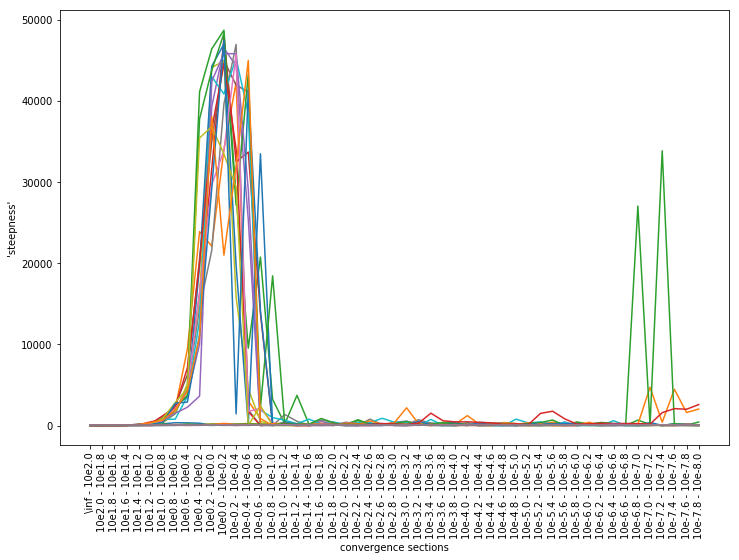

```python
# Now we plot all differences for each configuration that is best between at least one pair of targets
subset = selectSmallestPerColumn(df_diff, columns)
fig, ax = plt.subplots(figsize=(12,8))
plotOnAxis(subset, columns, ax, legend=False)
plt.show()
```

We get some really large values here, which are actually not what we want to see: higher values mean bad performance.

Instead, at least to visualize, it's more interesting to look at the 1/$\delta$'s.

```python
def makecleaninverses(df, columns):
    return_df = df.copy()
    for col in columns:
        return_df[col] = 1/df[col]
    return_df = return_df.replace(np.inf, np.NaN)
    return return_df
```

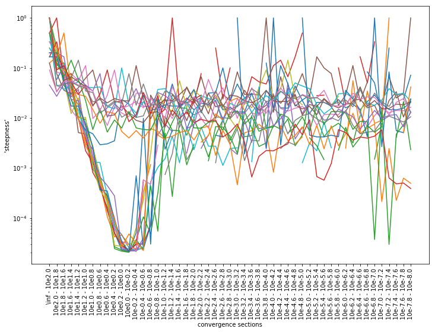

```python
# Now we plot all differences for each configuration that is best between at least one pair of targets
subset = makecleaninverses(selectSmallestPerColumn(df_diff, columns), columns)
fig, ax = plt.subplots(figsize=(12,8))
plotOnAxis(subset, columns, ax, legend=False)
plt.yscale('log')
plt.show()
```

```python
#SOME DEBUGGING INFO
# idx = df_diff[columns[14]].nsmallest(1).axes[0]
# print(idx)
# rep = df_diff.iloc[idx]['Representation'].values[0]
# print(rep)

# subset = df[df['Representation'] == rep]

# print(idx)
# print(subset.as_matrix(columns).astype(int))
# print(df_diff.iloc[idx].as_matrix(columns))

#SOME DEBUGGING INFO
# print(absolutetodifferences(aggregateByMean(subset)).as_matrix(columns).astype(int))
```

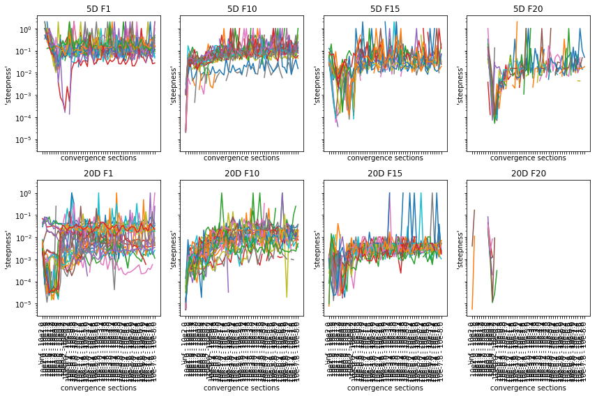

```python
# Because it's defined as a simple-to-use function, we can now plot this data for all available datasets
fig, axes = plt.subplots(ncols=4, nrows=2, figsize=(12,8), sharex=True, sharey=True)

for exp, ax in zip(product(ndims, fids), axes.flatten()):
    ndim, fid = exp
    df_means = aggregateByMean(absolutetodifferences(get_data(ndim=ndim, fid=fid)))
    subset = makecleaninverses(selectSmallestPerColumn(df_means, columns), columns)
    plotOnAxis(subset, columns, ax, title='{}D F{}'.format(ndim, fid), legend=False)
    ax.set_yscale('log')

plt.tight_layout()
plt.show()
```

```python
df_diff = absolutetodifferences(get_data(ndim=5, fid=1))
df_diff[columns] = df_diff[columns].replace(0, np.NaN)
df_diff = aggregateByMax(df_diff)
subset = selectSmallestPerColumn(df_diff, columns)

# And now the hypothetical result if we take the best sub-result per section...
print(subset[columns].min(axis=0))
print(subset[columns].min(axis=0).sum())
```

```
10e2.0      1.0
10e1.8      1.0
10e1.6      2.0
10e1.4      7.0
10e1.2      7.0
10e1.0      9.0
10e0.8     11.0
10e0.6     13.0
10e0.4     11.0
10e0.2     11.0
10e0.0     10.0
10e-0.2    13.0
10e-0.4     9.0
10e-0.6     8.0
10e-0.8    15.0
10e-1.0    11.0
10e-1.2     1.0
10e-1.4     1.0
10e-1.6     2.0
10e-1.8     1.0
10e-2.0     1.0
10e-2.2     1.0
10e-2.4     4.0
10e-2.6     4.0
10e-2.8     1.0
10e-3.0     5.0
10e-3.2     1.0
10e-3.4     2.0
10e-3.6     4.0
10e-3.8     3.0
10e-4.0     1.0
10e-4.2     1.0
10e-4.4     5.0
10e-4.6     2.0
10e-4.8     1.0
10e-5.0     1.0
10e-5.2     4.0
10e-5.4     1.0
10e-5.6     1.0
10e-5.8     1.0
10e-6.0     2.0
10e-6.2     1.0
10e-6.4     1.0
10e-6.6     4.0
10e-6.8     1.0
10e-7.0     1.0
10e-7.2     3.0
10e-7.4     1.0
10e-7.6     1.0
10e-7.8     1.0
10e-8.0     1.0
dtype: float64
205.0
```

```python
def calcresults():
    records = []
    labels = ['ndim', 'fid', 'Target', 'Empirical best', 'Adaptive best', 'Relative improvement']
    for ndim, fid in product(ndims, fids):
        df = get_data(ndim=ndim, fid=fid)

        df_means = aggregateByMean(df)
        actual_best = np.NaN
        col_idx = 1
        while np.isnan(actual_best):
            actual_best = df_means[columns[-col_idx]].min()
            col_idx += 1

        df_diff = absolutetodifferences(df)
        df_diff[columns] = df_diff[columns].replace(0, np.NaN)
        df_diff = aggregateByMax(df_diff)
        subset = selectSmallestPerColumn(df_diff, columns)
        theory_best = subset[columns].min(axis=0).sum()

        rel_improvement = 1-(theory_best/actual_best)

        records.append((ndim, fid, columns[-col_idx+1], actual_best, theory_best, rel_improvement))

    results = pd.DataFrame.from_records(records, columns=labels)
    return results

print(calcresults())
```

```
   ndim  fid   Target  Empirical best  Adaptive best  Relative improvement
0     5    1  10e-8.0           406.5          205.0              0.495695
1     5   10  10e-8.0          1358.0          772.0              0.431517
2     5   15  10e-8.0           750.0          519.0              0.308000
3     5   20  10e-8.0           623.0          284.0              0.544141
4    20    1  10e-8.0          1234.5          671.0              0.456460
5    20   10  10e-8.0         16461.0        10614.0              0.355203
6    20   15  10e-8.0         50189.0         1941.0              0.961326
7    20   20  10e-0.2         11342.0         4041.0              0.643714
```